# Week_10_VO2

# Looking for normality in residual values

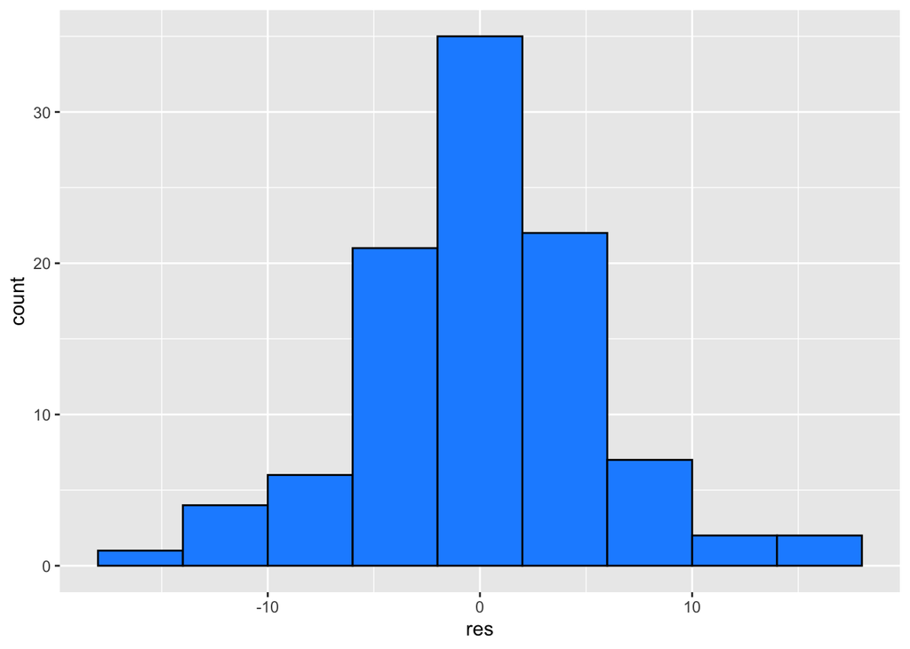

```r
ggplot(data = NULL, aes(x = res)) +
  geom_histogram(colour = "black", fill = "dodgerblue", binwidth = 4)
```

### distribution looks normal, with possible long tails either end.

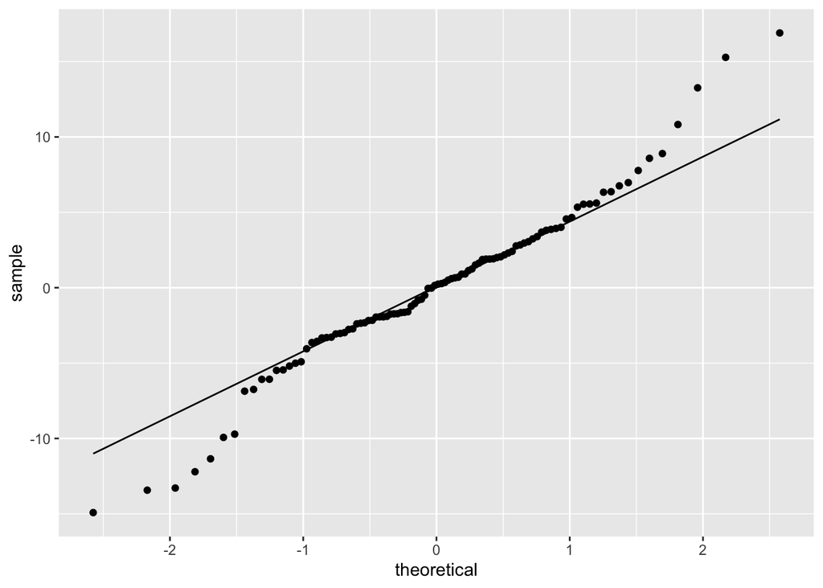

```r
ggplot(data = NULL, aes(sample = res)) +
  stat_qq() + stat_qq_line()
```

# Perhaps some longer tails at either end. # To fix this we could transfrom our data

# Test for multicollinearity

```r
car::vif(fit)
```

```
##        age     weight heart_rate     gender
##   1.005238   1.306352   1.057685   1.300843
```

# All vif values are quite close to 1 so does not appear to be any

# multicollinearity influencing the standard errors of the coefficients

## Linearity

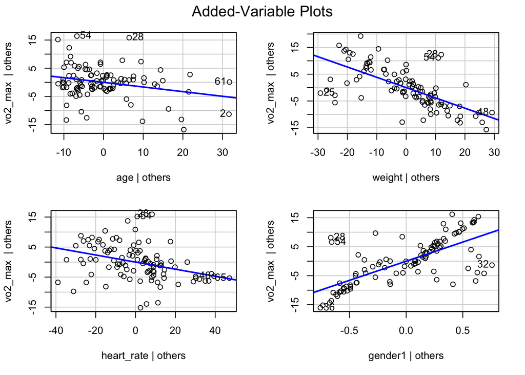

```r
car::avPlots(fit)
```

# Some points are tending to create non-linear patterns in the data, they seem to be similar to the points # that may have been points of high influence. # We could try transforming our data or investigate the use of a different model that is more robust to our data

# Step 15. Interpretation:

# estimated VO2max = 87.8 + age x -0.165 + weight x -0.385 + heart rate x -0.118 + gender x 13.2

# estimated VO2max

```r
87.8 + 31 * -0.165 + 68 * -0.385 + 140 * -0.118 + 0 * 13.2 ## information comes from the summary(fit)
```

```
## [1] 39.985
```

# Some of our assumptions may have been violated and we potentially need to apply a transformation (e.g. log transformation) to our

# explanatory variables, response variable or both

# we should investigate non-linear models that could be more robust to the data we have as well

# we should also investigate the level of error in our estimates (i.e. difference between observed and predicted values)